# Lecture notes KNN

```python
%run import.py
```

```python
# import image module
from IPython.display import Image

# get the image
Image(url="Under_and_over_fitting.png", width=900, height=900)
```

[figure not shown]

## K Nearest Neighbors (K-NN)

### K-NN Classifier

The simplest version of the K-NN algorithm only considers the nearest training point to make a prediction. The figure belo illistrates this using the `Forge` dataset

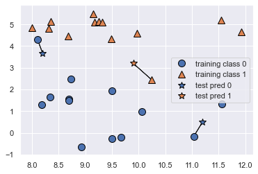

```python
 mglearn.plots.plot_knn_classification(n_neighbors=1)
```

We can also comnsider an arbitary number, k, of neighbors. This is where the algorithm gets its name. when considering more than one neighbor the prediction is made using voting.

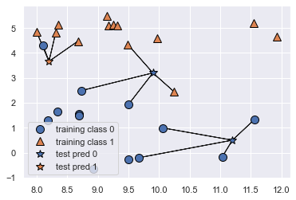

```python
mglearn.plots.plot_knn_classification(n_neighbors=4)
```

Now lets look at how we implement K-NN in scikit learn. First we will split our data into test data and training data:

```python
from sklearn.model_selection import train_test_split
X, y = mglearn.datasets.make_forge()
X_train, X_test, y_train, y_test = train_test_split(X, y, random_state=0)
```

Next, we import and instantiate the class. This is when we can set parameters, like the number of neighbors to use. Here, we set it to 4:

```python
from sklearn.neighbors import KNeighborsClassifier
Knn_class= KNeighborsClassifier(n_neighbors=4)
```

Next we fit the classifier to our training set

```python
Knn_class.fit(X_train,y_train)
```

```
KNeighborsClassifier(n_neighbors=4)
```

```python
print("Test set predictions:", Knn_class.predict(X_test))
```

```
Test set predictions: [1 0 1 0 1 0 0]
```

```python
print("Test set accuracy: {:.2f}".format(Knn_class.score(X_test, y_test)))
```

```
Test set accuracy: 0.86
```

For a two-dimensional feature space we can visualize the prediction for all test points in the xy-plane. We can color each plane based on the class that would be assigned to a point in that region. From this we get a view of the *Decision Boundary*, which divides the plane into different classes.

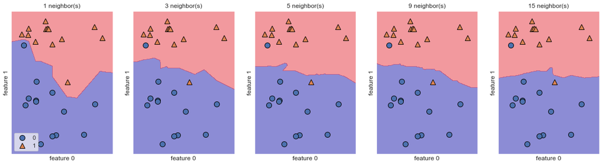

```python
fig, axes = plt.subplots(1, 5, figsize=(20, 5))
for n_neighbors, ax in zip([1, 3, 5, 9, 15], axes):
    # the fit method returns the object self, so we can instantiate
    # and fit in one line
    clf = KNeighborsClassifier(n_neighbors=n_neighbors).fit(X, y)
    mglearn.plots.plot_2d_separator(clf, X, fill=True, eps=0.5, ax=ax, alpha=.4)
    mglearn.discrete_scatter(X[:, 0], X[:, 1], y, ax=ax)
    ax.set_title("{} neighbor(s)".format(n_neighbors))
    ax.set_xlabel("feature 0")
    ax.set_ylabel("feature 1")
axes[0].legend(loc=3);
```

The Decision Boundary on the left follows the training data very closely. Considereing more and more neigbors leads to a smoother boundary which corresponds to a simpler model. few neighbors corresponds to high model complexity (overfitting), and using many neighbors corresponds to low model complexity (underfitting)

Now let us investigate the connection between complexity and generalization using knn. We will do this using realworld Breast Cancer data.

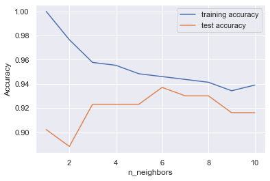

```python
from sklearn.datasets import load_breast_cancer
cancer = load_breast_cancer()
X_train, X_test, y_train, y_test = train_test_split(cancer.data, cancer.target, stratify=cancer.target, random_state=66)
training_accuracy = []
test_accuracy = []
# try n_neighbors from 1 to 10
neighbors_settings = range(1, 11)
for n_neighbors in neighbors_settings:
    # build the model
    clf = KNeighborsClassifier(n_neighbors=n_neighbors)
    clf.fit(X_train, y_train)
    # record training set accuracy
    training_accuracy.append(clf.score(X_train, y_train))
    # record generalization accuracy
    test_accuracy.append(clf.score(X_test, y_test))
plt.plot(neighbors_settings, training_accuracy, label="training accuracy")
plt.plot(neighbors_settings, test_accuracy, label="test accuracy")
plt.ylabel("Accuracy")
plt.xlabel("n_neighbors")
plt.legend()
```

For a single neighbor the prediction on the training set is perfect and the prediction of the training set is not bad. As the number of neighbors increases the training accuracyt decreases as expected. The test accuracy increases and then decreases, so the optimal number of neighbors for this model would be 6.

### K-NN Regresion

There is aslo a regression variant of the K-NN algorithm. We can start by looking at a single neighbor using the wave data set

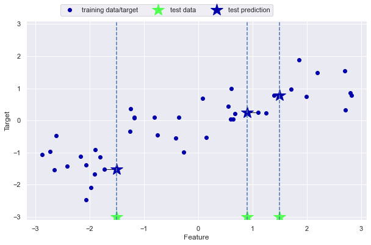

```python
mglearn.plots.plot_knn_regression(n_neighbors=1)
```

We can also increase the number of meighbors. Here when using multiple nearest neighbors the prediction is the average of the neighbors.

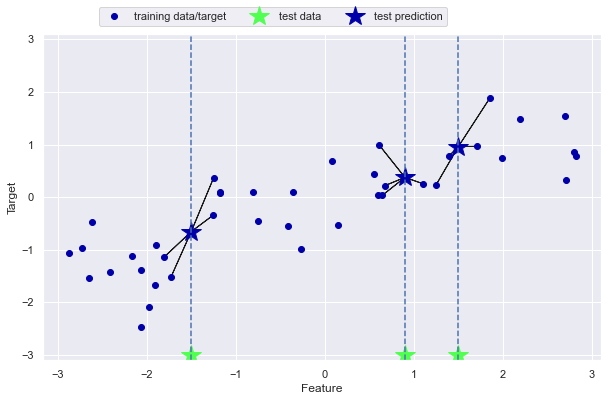

```python
mglearn.plots.plot_knn_regression(n_neighbors=4)
```

K-NN for regression is implemeneted in the same way as the classifier in `scikit-learn`

```python
from sklearn.neighbors import KNeighborsRegressor
X, y = mglearn.datasets.make_wave(n_samples=40)
# split the wave dataset into a training and a test set
X_train, X_test, y_train, y_test = train_test_split(X, y, random_state=0)
# instantiate the model and set the number of neighbors to consider to 4
reg = KNeighborsRegressor(n_neighbors=4)
# fit the model using the training data and training targets
reg.fit(X_train, y_train)
```

```
KNeighborsRegressor(n_neighbors=4)
```

We can make predictions as before by using the predict method:

```python
print("Test set predictions:\n", reg.predict(X_test))
```

```
Test set predictions:
 [-0.01608317  0.33124259  0.90992981 -1.83887615 -1.13528323 -1.84134095
  0.13580868  1.0578532  -0.31071247 -1.13528323]
```

We can evalute the model using the score method just as with the calssifier. Here the score method gives the $R^2$ score, also known as the coefficient of determinnation.

```python
print("Test set R^2: {:.2f}".format(reg.score(X_test, y_test)))
```

```
Test set R^2: 0.77
```

We can anclyze the regression modle simlar to how we analyzed the classifier model

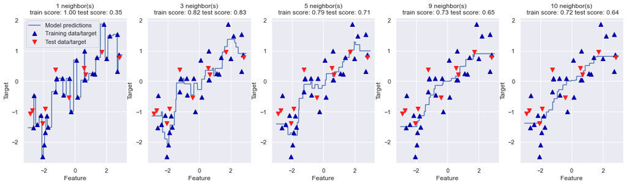

```python
fig, axes = plt.subplots(1, 5, figsize=(20, 5))
# create 1,000 data points, evenly spaced between -3 and 3
line = np.linspace(-3, 3, 1000).reshape(-1, 1)
for n_neighbors, ax in zip([1, 3,5, 9,10], axes):
        # make predictions using 1, 3, or 9 neighbors
        reg = KNeighborsRegressor(n_neighbors=n_neighbors)
        reg.fit(X_train, y_train)
        ax.plot(line, reg.predict(line))
        ax.plot(X_train, y_train, '^', c=mglearn.cm2(0), markersize=8)
        ax.plot(X_test, y_test, 'v', c=mglearn.cm2(1), markersize=8)
        ax.set_title("{} neighbor(s)\n train score: {:.2f} test score: {:.2f}".format(n_neighbors, reg.score(X_train, y_train),reg.score(X_test, y_test)))
        ax.set_xlabel("Feature")
        ax.set_ylabel("Target")
axes[0].legend(["Model predictions", "Training data/target",
                    "Test data/target"], loc="best")
```

### Strengths, weaknesses, and paramters

There are 2 important parameters when considering K-nearest neighbors algorithm: the number of neighbors and how distance is measured. On of the sttrenghts of K-NN is it is a simple model and easy to understand. This method is a good baseline before trying ore considerin more advanced techniques. This approach does not preform well when there are 100's of features or and or when most features are 0 most of the time (sparse datasets)